# Series 3 of 10 – How to Compare Two Groups with Robust Bayesian Estimation

Biostatistics

Bayesian Methods

R

JAGS/Stan

4 years ago, the argument about the stop relying 100% on null hypothesis significance testing (NHST) which was the P-VALUE. A very appealing alternative to NHST is Bayesian statistics, which in itself contains many approaches to statistical inference. In this post, I provide an introductory and practical tutorial to Bayesian parameter estimation in the context of comparing two independent groups’ data based on the adaption of UC’s lecture and Kruschke’s textbook (Chapter 16).

Hai Nguyen  
January 15, 2022

# Setting to compare two groups (w/ no predictors)

## IQ data

One example of two-groups problem is testing effect of a drug when one group receives a placebo and another receives the drug. The response variable is result of IQ test.

In this example we estimate mean and standard deviation for two groups using normal distribution, then robust $t$-distribution with common normality parameter $\lambda$.

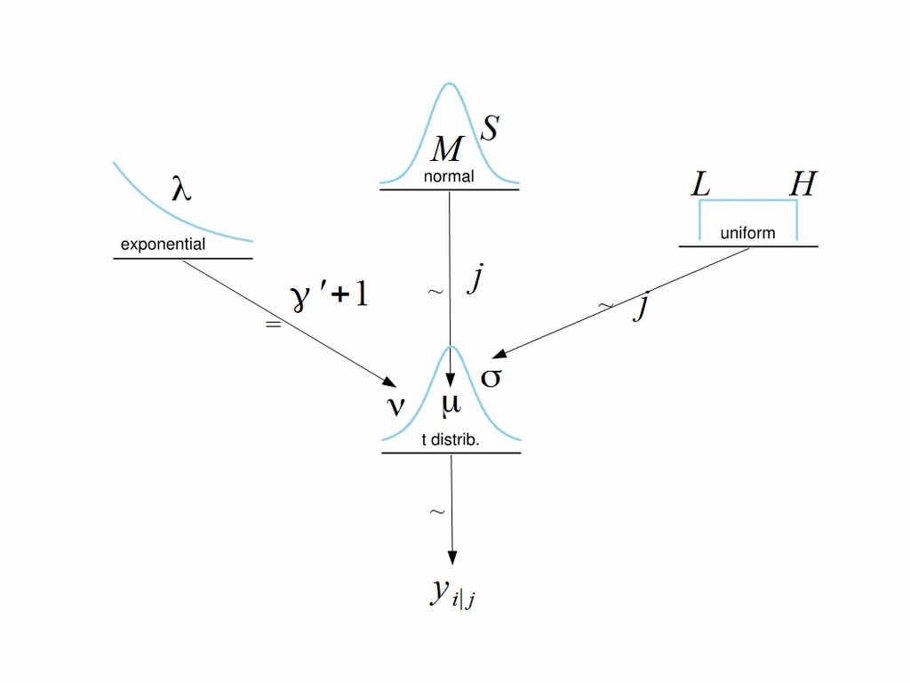

The diagram of the model structure shows how the model needs to be coded.

### Data.

```r
dta <- read.csv("data/IQdrug.csv")
DT::datatable(dta)
```

|  | Score | Group |
| --- | --- | --- |
| 1 | 102 | Smart Drug |
| 2 | 107 | Smart Drug |
| 3 | 92 | Smart Drug |
| 4 | 101 | Smart Drug |
| 5 | 110 | Smart Drug |
| 6 | 68 | Smart Drug |
| 7 | 119 | Smart Drug |
| 8 | 106 | Smart Drug |
| 9 | 99 | Smart Drug |
| 10 | 103 | Smart Drug |

[output cut: 110 more lines]

### Prepare data

```r
y <- as.numeric(dta[,"Score"])
x <- as.numeric(as.factor(dta[,"Group"]))

(xLevels <- levels(as.factor(dta[,"Group"])))
```

```
[1] "Placebo"    "Smart Drug"
```

```r
Ntotal = length(y)

# Specify the data in a list for JAGS/Stan:
dataList = list(
    y = y,
    x = x,
    Ntotal = Ntotal,
    meanY = mean(y),
    sdY = sd(y)
)
```

## Call `Stan`

```r
#source("../DBDA2Eprograms/DBDA2E-utilities.R")
library(rstan)
options(mc.cores = parallel::detectCores())
rstan_options(auto_write = TRUE)
```

## Normal assumption

Assuming that both groups samples have normal distributions, estimate the parameters and compare them.

Write description of the model for stan.

$$y_{i\mid j} \sim N(\mu_j, \sigma^2_j) \\
\mu_j \sim N(\bar{Y}, \frac{1}{100*SD_Y^2}) \\
\sigma_j \sim uniform(\frac{SD_Y}{1000}, SD_Y*1000)$$

```r
# Use the description for Stan from file "ch16.2.stan"
modelString = "
data {
    int<lower=1> Ntotal;
    int x[Ntotal];
    real y[Ntotal];
    real meanY;
    real sdY;
}
transformed data {
    real unifLo;
    real unifHi;
    real normalSigma;
    unifLo = sdY/1000;
    unifHi = sdY*1000;
    normalSigma = sdY*100;
}
parameters {
    real mu[2];
    real<lower=0> sigma[2];
}
model {
    sigma ~ uniform(unifLo, unifHi);
    mu ~ normal(meanY, normalSigma);
    for ( i in 1:Ntotal ) {
        y[i] ~ normal(mu[x[i]] , sigma[x[i]]);
    }
}
"
```

If running the description in `modelString` for the first time create `stanDSONormal`, otherwise reuse it.

```r
stanDsoNormal <- stan_model(model_code=modelString)
```

If saved DSO is used load it, then run the chains.

```r
#saveRDS(stanDsoNormal, file="data/DSONormal1.Rds")
stanDsoNormal<-readRDS("data/DSONormal1.Rds")
```

Run MCMC.

```r
parameters = c("mu","sigma")     # The parameters to be monitored
adaptSteps = 500               # Number of steps to "tune" the samplers
burnInSteps = 1000
nChains = 4
thinSteps = 1
numSavedSteps = 5000
stanFitNormal <- sampling(stanDsoNormal,
                   data = dataList,
                   pars = parameters, # optional
                   chains = nChains,
                   iter = (ceiling(numSavedSteps/nChains)*thinSteps+burnInSteps),
                   warmup = burnInSteps,
                   init = "random", # optional
                   thin = thinSteps)
```

Save the fit object for further analysis.

```r
# save(stanFitNormal,file="data/StanNormalFit2Groups.Rdata")
load("data/StanNormalFit2Groups.Rdata")
```

**Then, we can explore the results.**

### Stan in regular way

```r
# text statistics:
print (stanFitNormal)
```

```
Inference for Stan model: a4cb1c74477f9a8b1e476a89a6556245.
4 chains, each with iter=2250; warmup=1000; thin=1;
post-warmup draws per chain=1250, total post-warmup draws=5000.

            mean se_mean   sd    2.5%     25%     50%     75%   97.5%
mu[1]     100.04    0.03 2.43   95.33   98.39  100.01  101.71  104.76
mu[2]     107.79    0.05 3.36  101.37  105.50  107.78  110.00  114.44
sigma[1]   18.34    0.03 1.81   15.28   17.07   18.22   19.44   22.38
sigma[2]   26.02    0.03 2.44   21.77   24.31   25.80   27.58   31.23
lp__     -423.27    0.03 1.47 -426.95 -424.00 -422.93 -422.20 -421.44
         n_eff Rhat
mu[1]     5453    1
mu[2]     5035    1
sigma[1]  5004    1
sigma[2]  5772    1
lp__      2598    1

Samples were drawn using NUTS(diag_e) at Mon Jan 30 00:57:34 2023.
For each parameter, n_eff is a crude measure of effective sample size,
and Rhat is the potential scale reduction factor on split chains (at
convergence, Rhat=1).
```

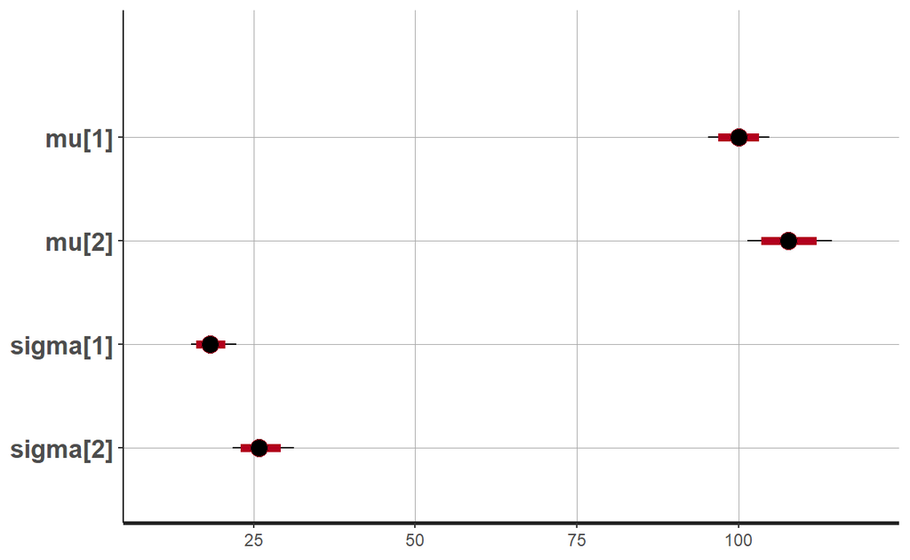

```r
# estimates & hdi:
plot(stanFitNormal)
```

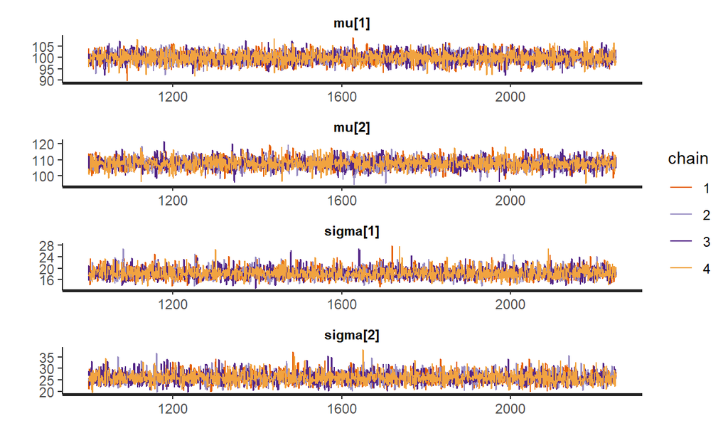

```r
# samples
rstan::traceplot(stanFitNormal, ncol=1, inc_warmup=F)
```

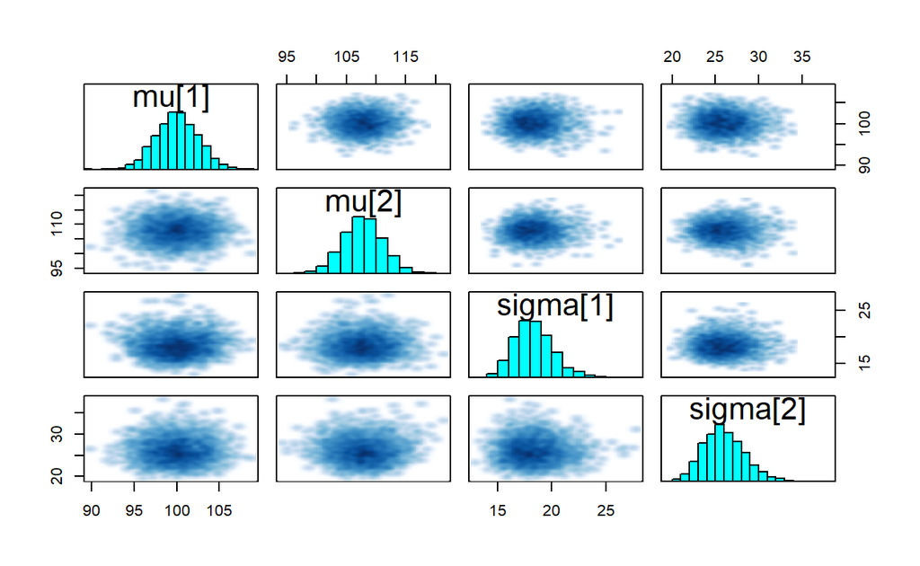

```r
pairs(stanFitNormal, pars=c('mu','sigma'))
```

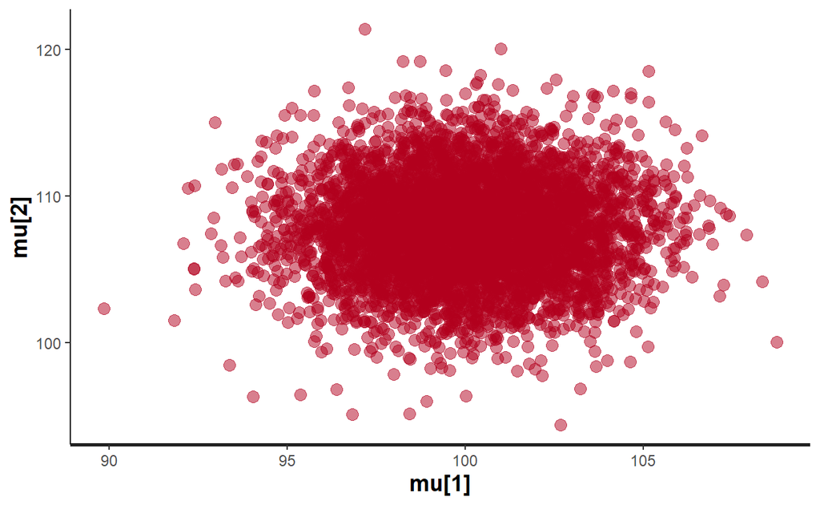

```r
stan_scat(stanFitNormal, c('mu[1]','mu[2]'))
```

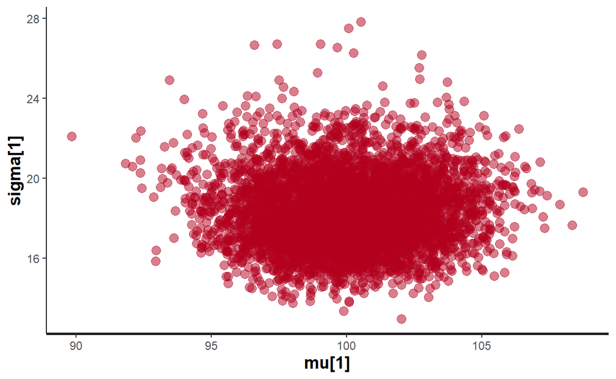

```r
stan_scat(stanFitNormal, c('mu[1]','sigma[1]'))
```

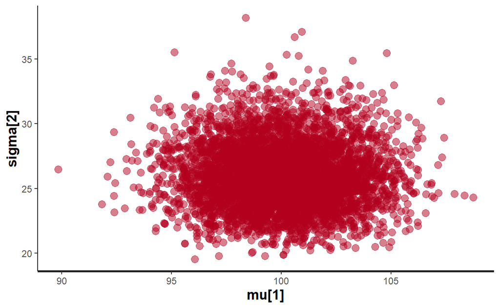

```r
stan_scat(stanFitNormal, c('mu[1]','sigma[2]'))
```

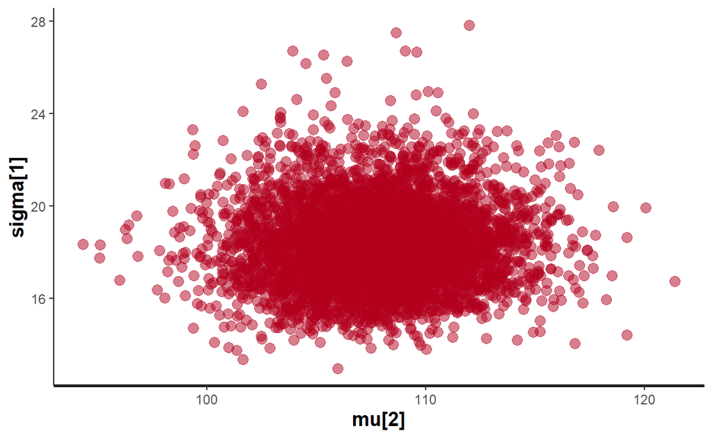

```r
stan_scat(stanFitNormal, c('mu[2]','sigma[1]'))
```

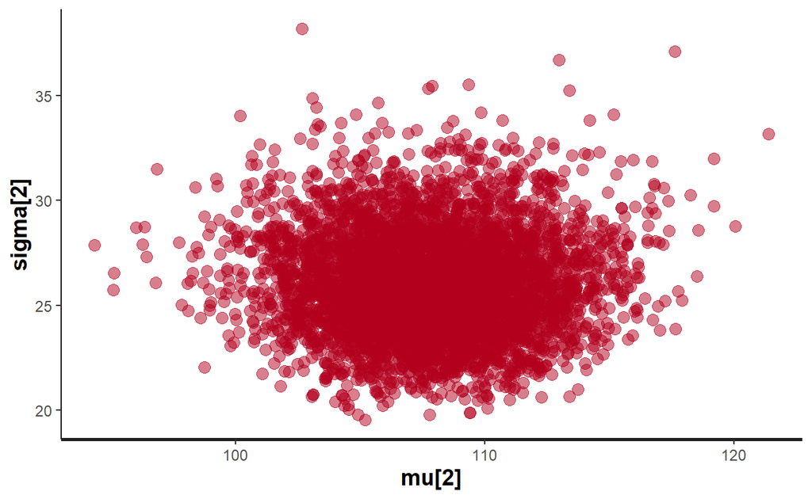

```r
stan_scat(stanFitNormal, c('mu[2]','sigma[2]'))
```

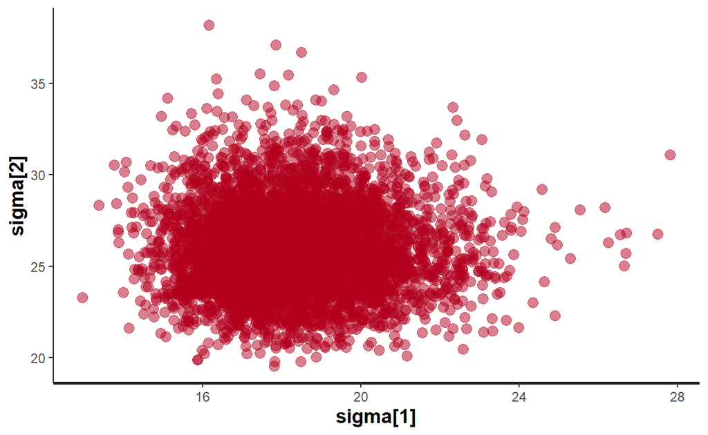

```r
stan_scat(stanFitNormal, c('sigma[1]','sigma[2]'))
```

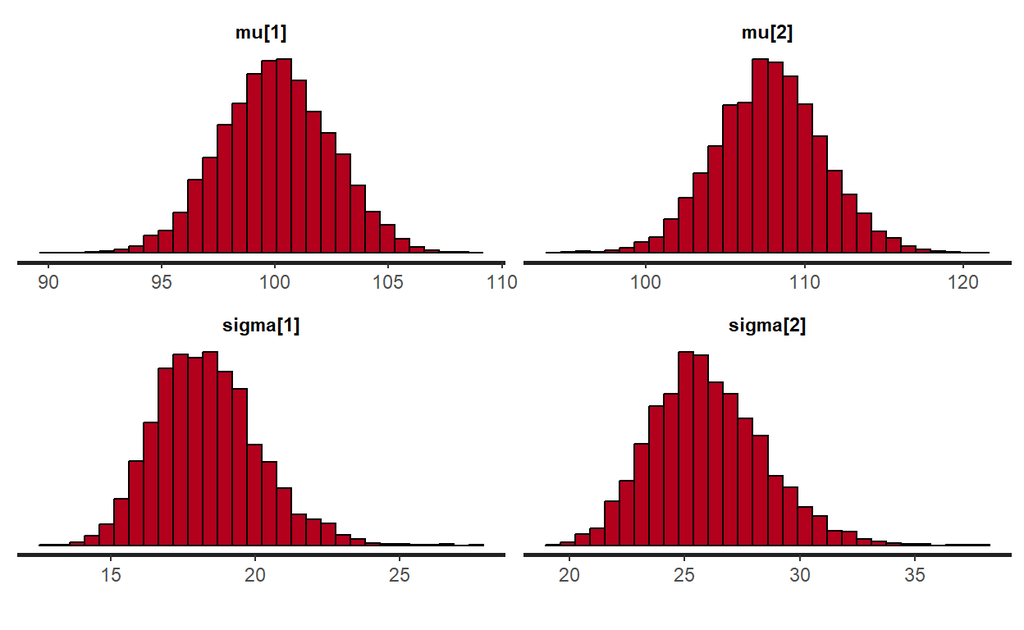

```r
stan_hist(stanFitNormal)
```

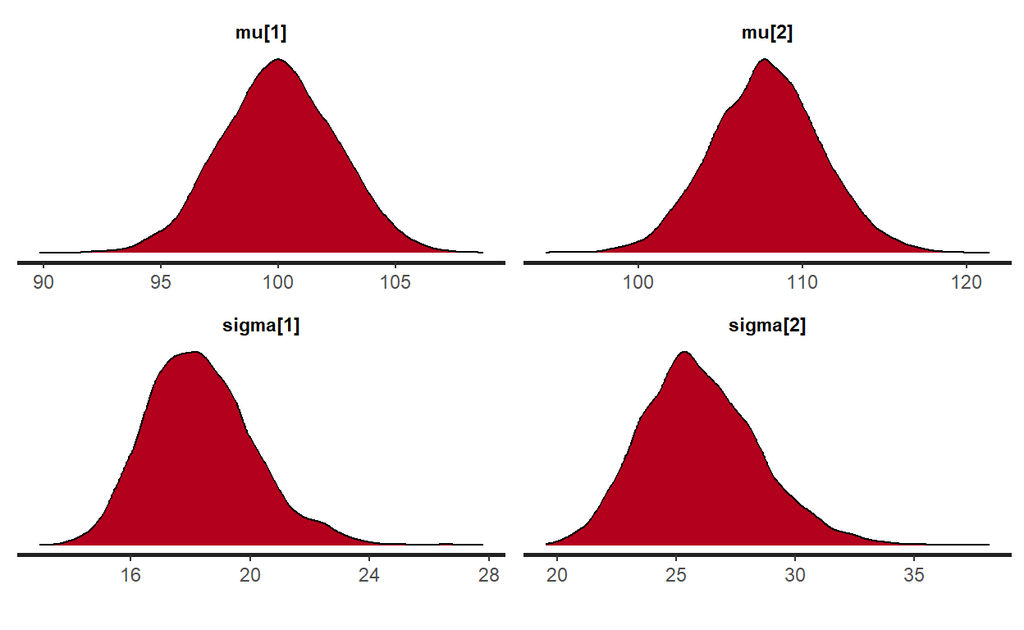

```r
stan_dens(stanFitNormal)
```

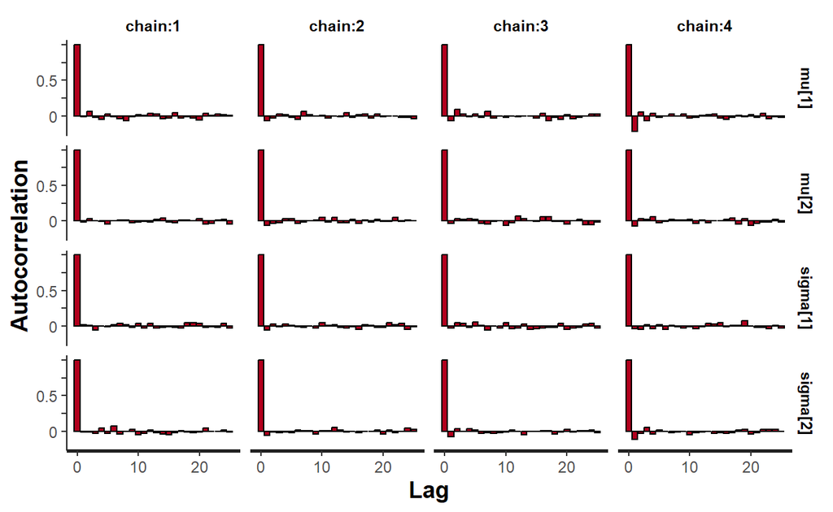

```r
# autocorrelation:
stan_ac(stanFitNormal, separate_chains = T)
```

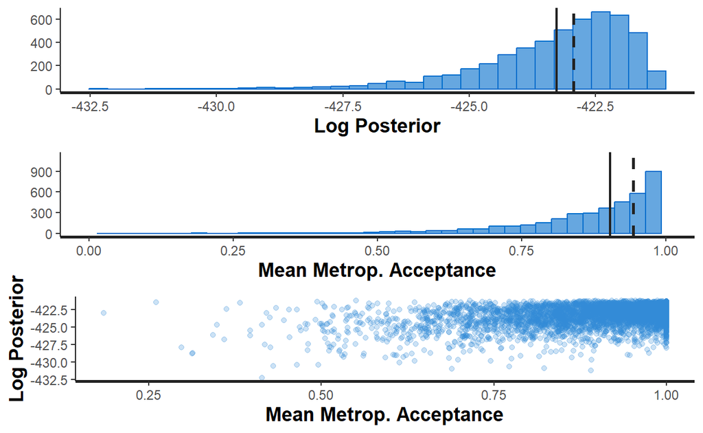

```r
stan_diag(stanFitNormal,information = "sample",chain=0)
```

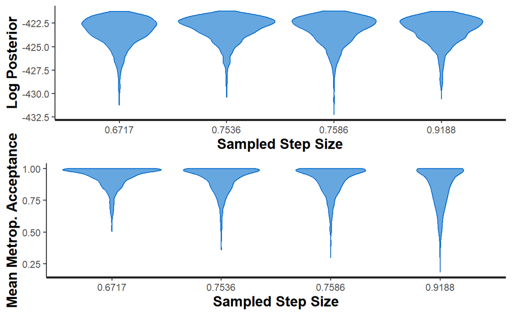

```r
stan_diag(stanFitNormal,information = "stepsize",chain = 0)
```

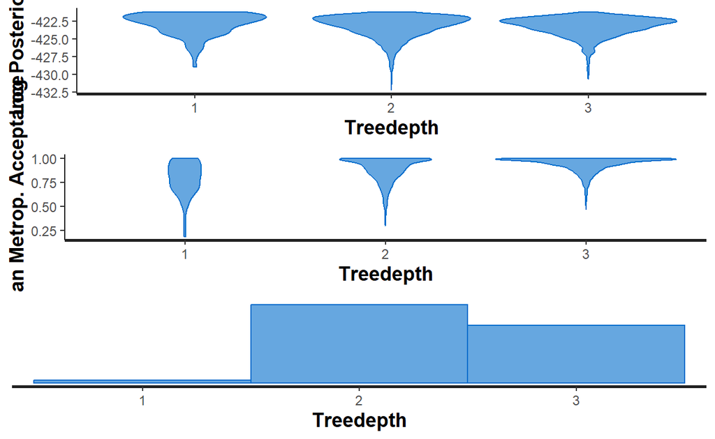

```r
stan_diag(stanFitNormal,information = "treedepth",chain = 0)
```

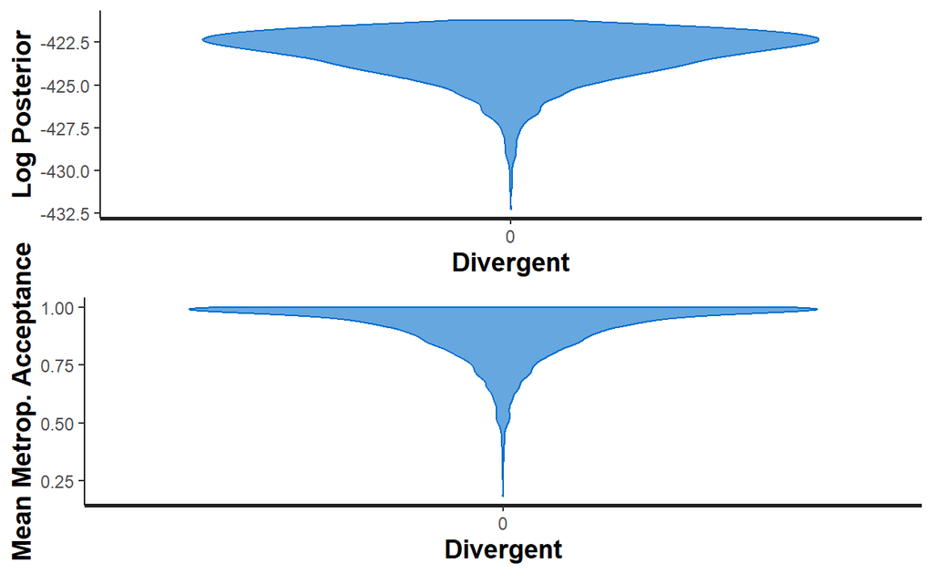

```r
stan_diag(stanFitNormal,information = "divergence",chain = 0)
```

### Coda

If we prefer output using coda class, reformat the chains into coda:

```r
library(coda)
stan2coda <- function(stanFitNormal) {
    # apply to all chains
    mcmc.list(lapply(1:ncol(stanFitNormal), function(x) mcmc(as.array(stanFitNormal)[,x,])))
}
codaSamples <- stan2coda(stanFitNormal)
summary(codaSamples)
```

```
Iterations = 1:1250
Thinning interval = 1
Number of chains = 4
Sample size per chain = 1250

1. Empirical mean and standard deviation for each variable,
   plus standard error of the mean:

            Mean    SD Naive SE Time-series SE
mu[1]     100.04 2.431  0.03438        0.03166
mu[2]     107.79 3.357  0.04748        0.04742
sigma[1]   18.34 1.806  0.02554        0.02516
sigma[2]   26.02 2.441  0.03452        0.03252
lp__     -423.27 1.465  0.02072        0.02860

2. Quantiles for each variable:

            2.5%     25%     50%     75%   97.5%
mu[1]      95.33   98.39  100.01  101.71  104.76
mu[2]     101.37  105.50  107.78  110.00  114.44
sigma[1]   15.28   17.07   18.22   19.44   22.38
sigma[2]   21.77   24.31   25.80   27.58   31.23
lp__     -426.95 -424.00 -422.93 -422.20 -421.44
```

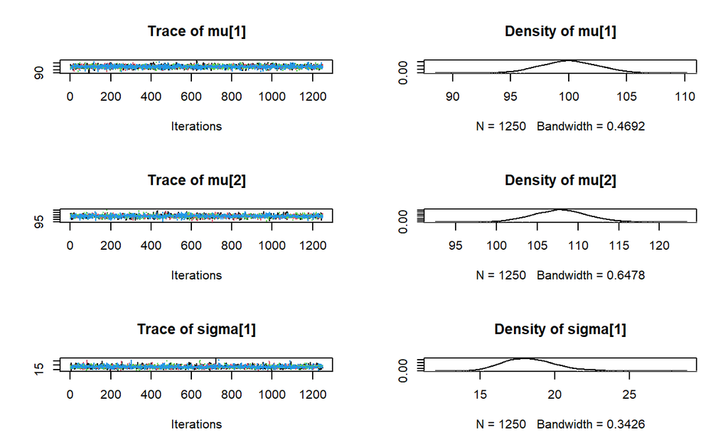

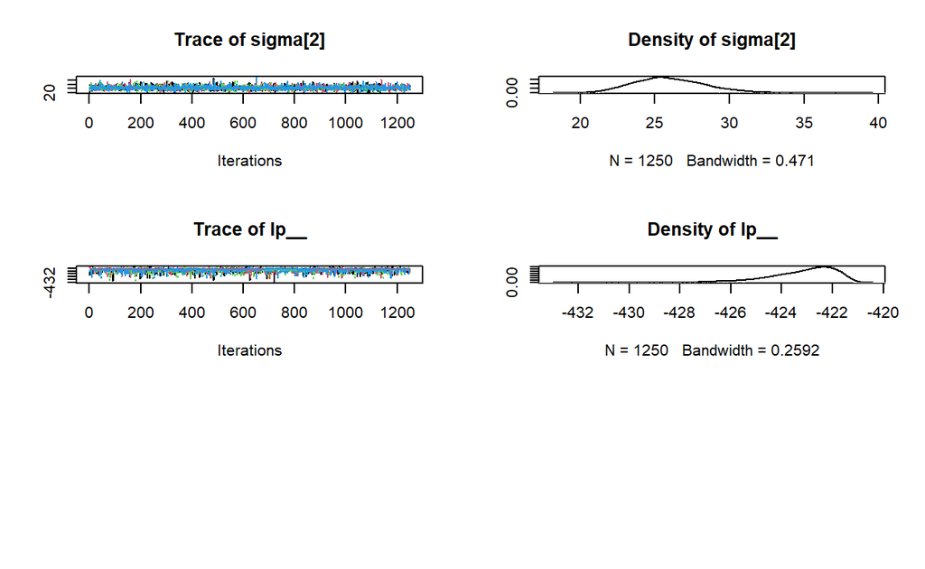

```r
plot(codaSamples)
```

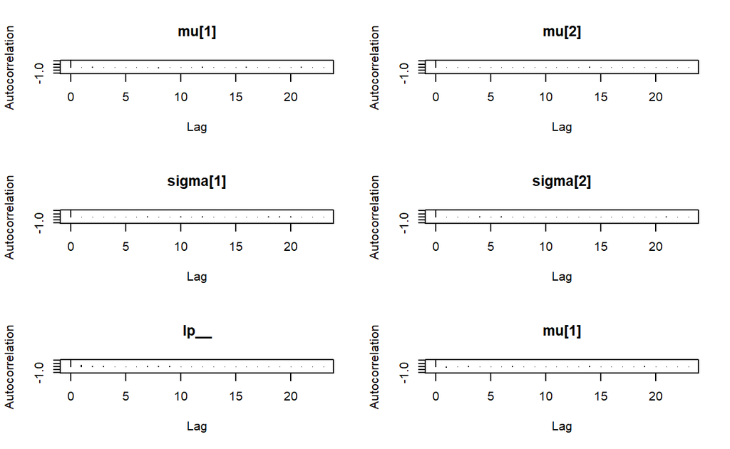

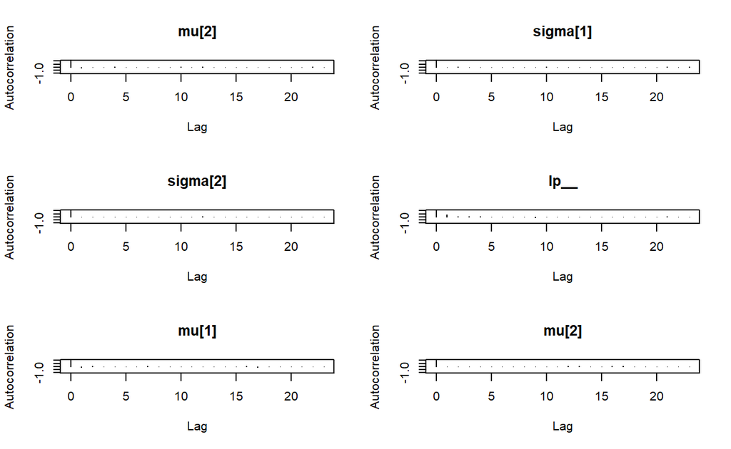

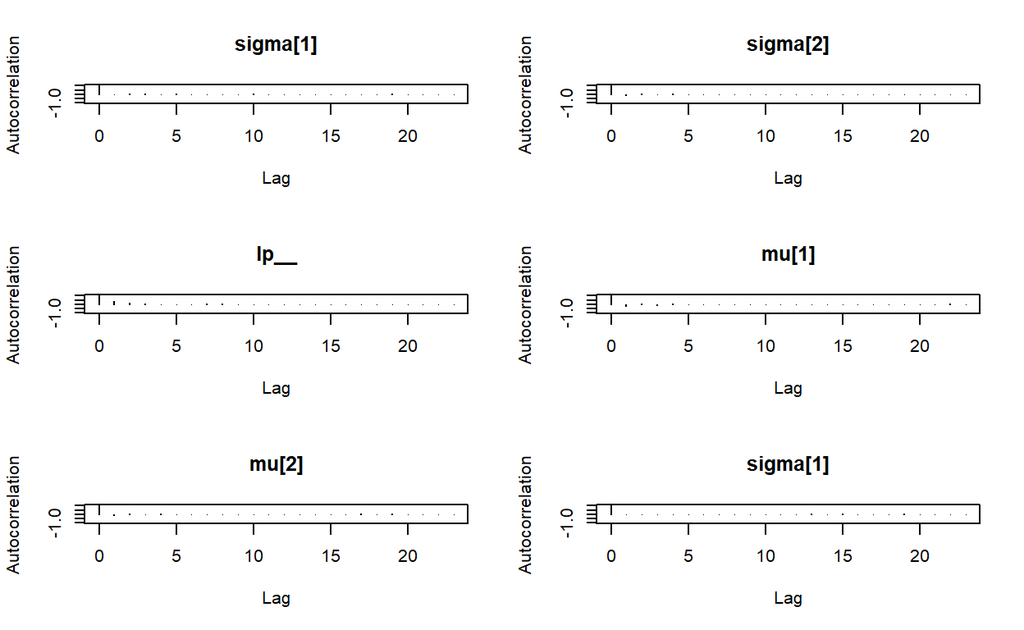

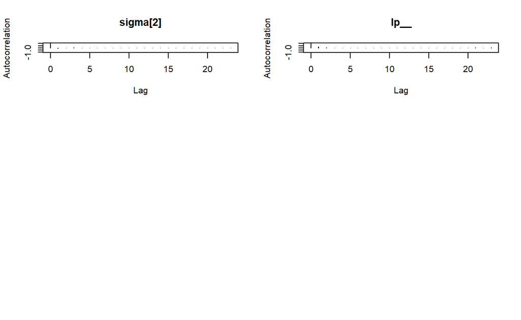

```r
autocorr.plot(codaSamples)
```

```r
effectiveSize(codaSamples)
```

```
   mu[1]    mu[2] sigma[1] sigma[2]     lp__
6113.262 5058.326 5239.336 5666.196 2646.550
```

```r
gelman.diag(codaSamples)
```

```
Potential scale reduction factors:

         Point est. Upper C.I.
mu[1]             1          1
mu[2]             1          1
sigma[1]          1          1
sigma[2]          1          1
lp__              1          1

Multivariate psrf

1
```

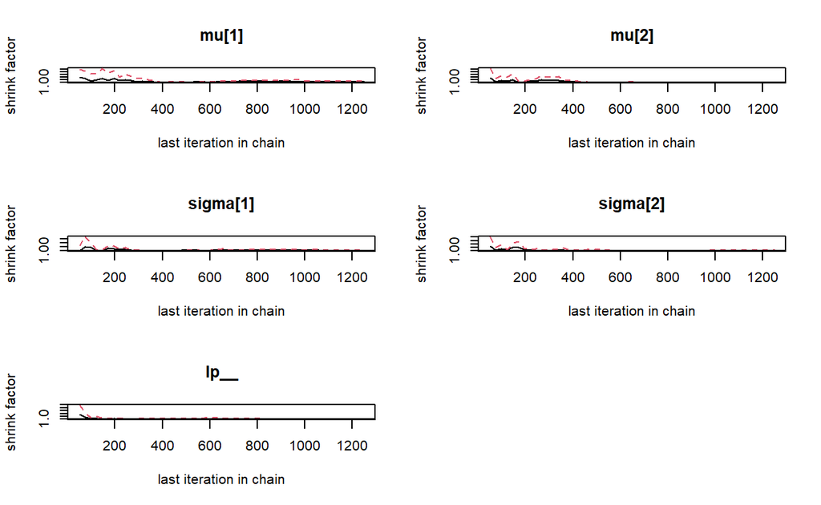

```r
gelman.plot(codaSamples)
```

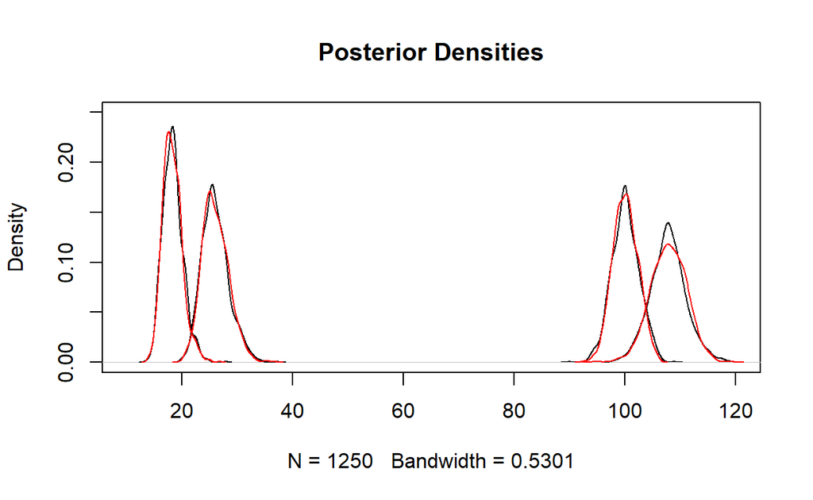

```r
plot(density(codaSamples[[1]][,1]),xlim=c(10,120),ylim=c(0,.25),main="Posterior Densities")  # mu[1], 1st chain
lines(density(codaSamples[[1]][,2]))                         # mu[2], 1st chain
lines(density(codaSamples[[1]][,3]))                         # sigma[1], 1st chain
lines(density(codaSamples[[1]][,4]))                         # sigma[2], 1st chain
lines(density(codaSamples[[2]][,1]),col="red")               # mu[1], 2nd chain
lines(density(codaSamples[[2]][,2]),col="red")               # mu[2], 2nd chain
lines(density(codaSamples[[2]][,3]),col="red")               # sigma[1], 2nd chain
lines(density(codaSamples[[2]][,4]),col="red")               # sigma[2], 2nd chain
```

### Shinystan

Or you can use shinystan to analyze fitted model

```r
library(shinystan)
```

Launch shiny application with the loaded object.

```r
launch_shinystan(stanFitNormal)
```

## Robust assumption

Use the robust assumption of Student-t distribution instead of normal distribution.

```r
modelString = "
data {
    int<lower=1> Ntotal;
    int x[Ntotal];
    real y[Ntotal];
    real meanY;
    real sdY;
}
transformed data {
    real unifLo;
    real unifHi;
    real normalSigma;
    real expLambda ;
    unifLo = sdY/1000;
    unifHi = sdY*1000;
    normalSigma = sdY*100;
    expLambda = 1/29.0;
}
parameters {
    real<lower=0> nuMinusOne;
    real mu[2] ; // 2 groups
    real<lower=0> sigma[2] ; // 2 groups
}
transformed parameters {
    real<lower=0> nu ;
    nu = nuMinusOne + 1 ;
}
model {
    sigma  ~ uniform( unifLo , unifHi ) ; // vectorized 2 groups
    mu ~ normal( meanY , normalSigma ) ; // vectorized 2 groups
    nuMinusOne ~ exponential( expLambda ) ;
    for ( i in 1:Ntotal ) {
      y[i] ~ student_t(nu, mu[x[i]] ,sigma[x[i]]) ; // nested index of group
    }
}
"
```

If running the description in modelString for the first time create stanDSO, otherwise reuse it.

```r
stanDsoRobust <- stan_model(model_code=modelString)
```

If saved DSO is used load it, then run the chains.

```r
# saveRDS(stanDsoRobust,file="data/DSORobust1.Rds")
stanDsoRobust<-readRDS(file="data/DSORobust1.Rds")
```

If necessary, initialize chains. Parameter `init` can be: one of digit 0, string “0” or “random”, a function that returns a list, or a list of initial parameter values with which to indicate how the initial values of parameters are specified.

- “0”: initialize all to be zero on the unconstrained support
- “random”: randomly generated
- list: a list of lists equal in length to the number of chains (parameter chains), where each list in the list of lists * specifies the initial values of parameters by name for the corresponding chain.
- function: a function that returns a list for specifying the initial values of parameters for a chain. The function can take an optional parameter chain_id.

Since Stan has pretty complicated parameter tuning process during which among other parameters it selects initial values, it may be a good idea to let Stan select default initial parameters until we get enough experience.

Run MCMC.

```r
parameters = c( "mu" , "sigma" , "nu" )     # The parameters to be monitored
adaptSteps = 500               # Number of steps to "tune" the samplers
burnInSteps = 1000
nChains = 4
thinSteps = 1
numSavedSteps<-5000
# Get MC sample of posterior:
stanFitRobust <- sampling( object=stanDsoRobust ,
                   data = dataList ,
                   pars = parameters , # optional
                   chains = nChains ,
                   cores=nChains,
                   iter = (ceiling(numSavedSteps/nChains)*thinSteps
                            + burnInSteps ) ,
                   warmup = burnInSteps ,
                   init = "random" , # optional
                   thin = thinSteps )
```

Save the fit object.

```r
# save(stanFitRobust,file="data/StanRobustFit2Groups.Rdata")
load("data/StanRobustFit2Groups.Rdata")
```

Explore the results.

```r
print(stanFitRobust)
```

```
Inference for Stan model: 3b61ff01c98dc80a0961c8bae33b0b6e.
4 chains, each with iter=2250; warmup=1000; thin=1;
post-warmup draws per chain=1250, total post-warmup draws=5000.

            mean se_mean   sd    2.5%     25%     50%     75%   97.5%
mu[1]      99.28    0.03 1.76   95.89   98.11   99.32  100.47  102.63
mu[2]     107.14    0.04 2.69  101.78  105.36  107.10  108.95  112.28
sigma[1]   11.32    0.03 1.75    8.28   10.11   11.21   12.40   15.06
sigma[2]   17.87    0.04 2.71   12.99   16.01   17.72   19.57   23.55
nu          3.87    0.03 1.71    1.91    2.82    3.51    4.42    8.15
lp__     -451.38    0.03 1.67 -455.61 -452.22 -451.03 -450.15 -449.20
         n_eff Rhat
mu[1]     4781    1
mu[2]     5127    1
sigma[1]  4350    1
sigma[2]  4679    1
nu        3694    1
lp__      2314    1

Samples were drawn using NUTS(diag_e) at Mon Jan 30 01:00:14 2023.
For each parameter, n_eff is a crude measure of effective sample size,
and Rhat is the potential scale reduction factor on split chains (at
convergence, Rhat=1).
```

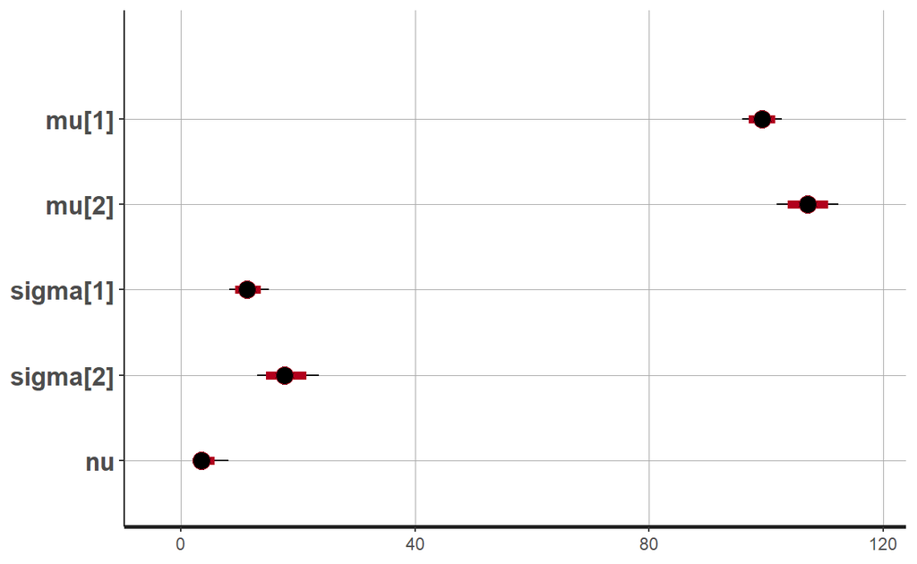

```r
plot(stanFitRobust)
```

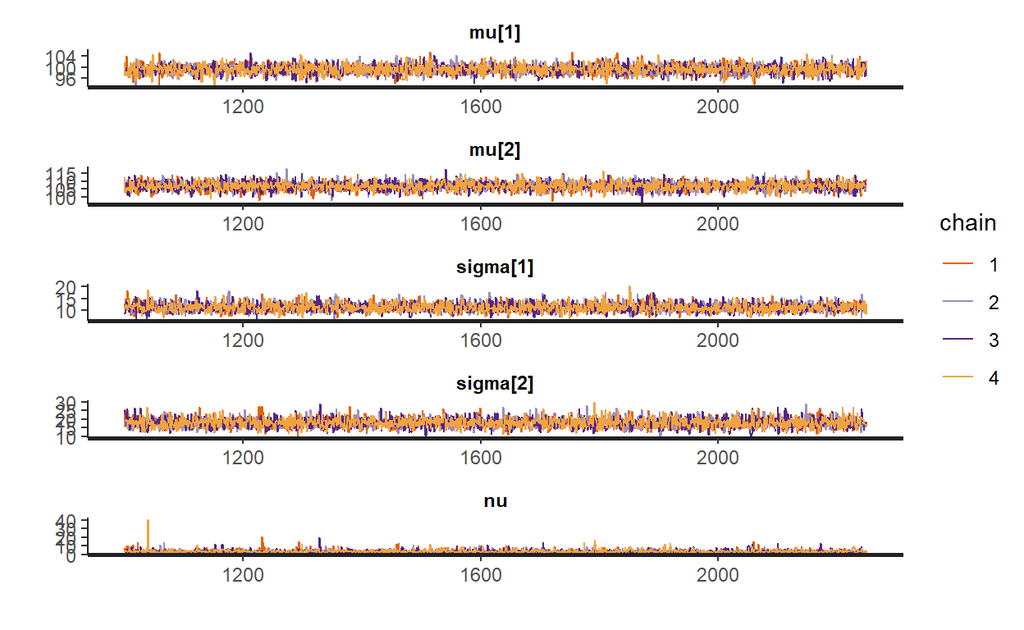

```r
rstan::traceplot(stanFitRobust, ncol=1, inc_warmup=F)
```

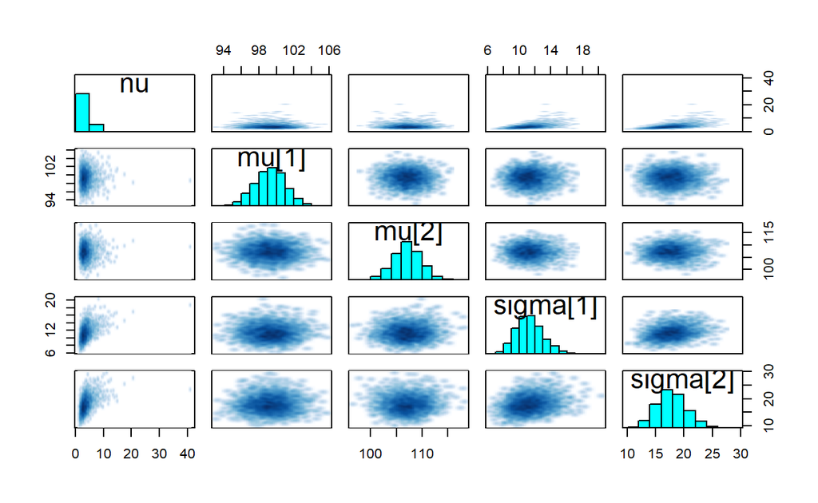

```r
pairs(stanFitRobust, pars=c('nu','mu','sigma'))
```